# Textmining in Economics

8. Oktober 2017

## Introduction

## Introduction

- In economics, empirical work is largely based on quantitative data (e.g. prices, demand, votes, etc.)
- But a large amount of unstructured text is also generated in economic environments (e.g. company reports, court decisions, media articles, etc.)
- At an abstract level, text is simply a string of characters
  - Latin alphabet ('a', 'A', 'p' and so on), Punctuation (e.g. !), Numbers,Non-alphanumerical characters (e.g. @)

**Key Question:** How can we obtain an informative, quantitative representation of these character strings?

## Concepts

- A single observation in a textual database is called a *document*.
- The set of documents that make up the dataset is called a *corpus*.
- Covariates associated with each document are called *metadata*.

## Example

In the text analysis ["Bundestagswahl 2017"](https://franziloew.github.io/politsentiment/election.html) we use a corpus of Tweets containing one of the parliamentary parties during the german parliamentary elections 2017:

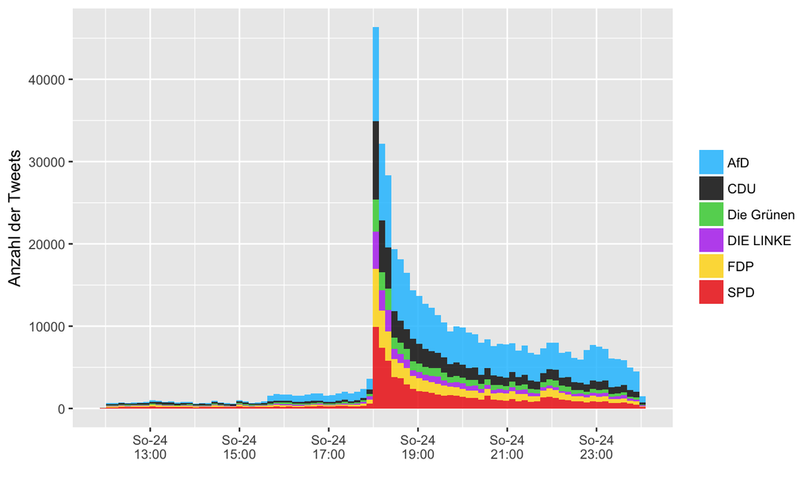

Text data is inherently high-dimensional, so an analysis of text usually tries to reduce this dimensionality following these steps:

1. **Pre-process** the text (Stopword removal, tokenization, stemming) and represent document \(D\) as a numerical array \(\boldsymbol{C}\) (e.g. bag-of-words model)
2. **Statistical Methods**
   - Map \(\boldsymbol{C}\) to predict values \(\boldsymbol{\hat{V}}\) of unknown outcomes \(\boldsymbol{V}\).
   - Sometimes the attribute of interest is latent (e.g. topics of a newspaper article)
3. Use \(\boldsymbol{\hat{V}}\) in subsequent **descriptive or causal analysis.**

## Represent text as Data

## Text Pre-Processing

1. **Tokenization** splitting of a raw character string into individual elements of interest: words, numbers, punctuation.
2. **Stopword Removal** Stopwords (highly frequent terms) are stripped out of token lists as they do not help distinguish one document from another.
3. **Linguistic Roots** For many applications, the relevant information in tokens is their linguistic root, not their grammatical form (e.g. treat "looking", "look", "looks" as equivalent tokens)
4. **Multi-Word Phrases** Sometimes groups of individual tokens like “United Kingdom” have a specific meaning (Use Ngrams)

## Cleaning Data (Example)

|  | text | text_cleaned |
| --- | --- | --- |
| 1 | "Das Land, Herr Gauland, gehört weder Ihnen noch der AfD. Und das Volk erst recht nicht." Kommentar des stv. ZDF-Ch… https://t.co/1ZvLZRP1rP | land herr gauland gehört weder afd volk erst recht kommentar stv zdf ch |
| 2 | Die AfD wird drittstärkste Kraft. Bernd Höcke rennt gerade über die Wahlparty und verteilt Heil-Fives. #BTW17 | afd drittstärkste kraft bernd höcke rennt gerade wahlparty verteilt heil fives btw |
| 3 | AfD: Ich bin kein Nazi. Trump: Ich bin kein Idiot. Erdogan: Ich bin kein Despot. BER: Ich bin ein fertiger Flughafen. | afd nazi trump idiot erdogan despot ber fertiger flughafen |
| 4 | AFD drittstärkste Partei! Wir haben keine Flüchtlingskrise, WIR HABEN EINE BILDUNGSKRISE!!! #BTW2017 | afd drittstärkste partei flüchtlingskrise bildungskrise btw |

## Tokenization

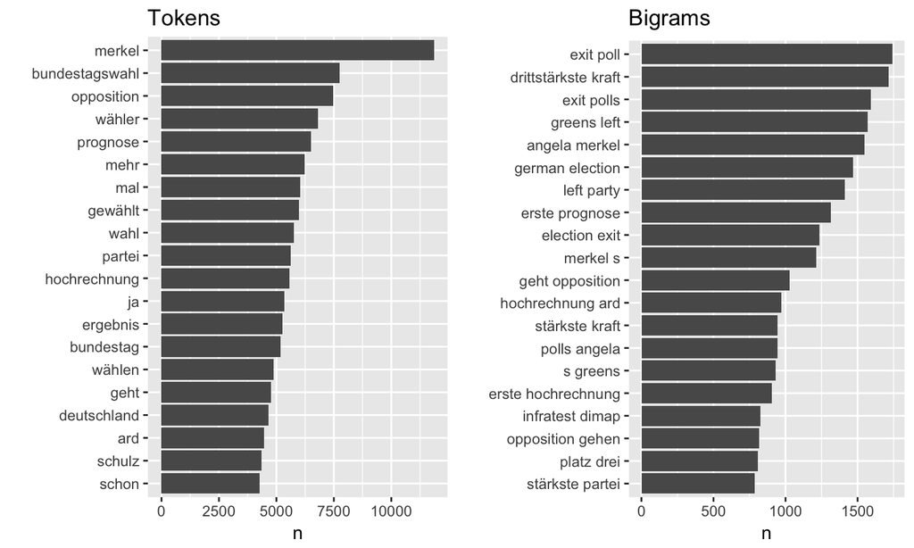

## Wordclouds

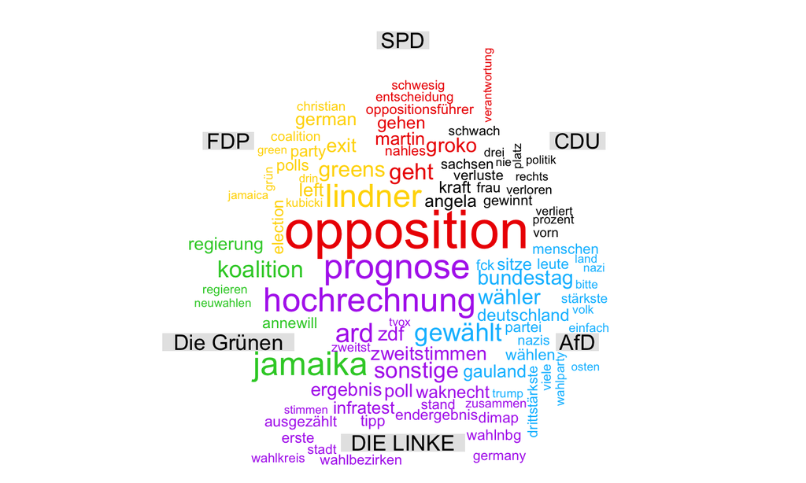

## What is the data?

After pre-processing, each document is a finite list of terms.

A basic quantitative representation of a corpus is the **bag-of-words model**

- Index each unique term in the corpus by some \(v \in {1,...,V}\) where \(V\) is the number of unique terms.
- For each document \(d \in {1,...,D}\) compute the count \(x_{d,v}\) as the number of occurrences of term \(v\) in document \(d\).
- The \(D x V\) matrix \(\boldsymbol{X}\) of all such counts is called the document-term matrix.

## Example

```r
Doc1 <-
  c("text", "mining", "is", "more", "fun", "than", "coal", "mining")
```

has the bag-of-words representation

```r
table(Doc1)
```

```
Doc1
  coal    fun     is mining   more   text   than
     1      1      1      2      1      1      1
```

But this has the same represantation:

```r
Doc1 <-
  c("coal", "mining", "is", "more", "fun", "than", "text", "mining")
```

## bag-of-words model

The bag-of-words model is useful for describing content, but we lose all information about sentence structure.

- Any useful representation of text will throw away some information; that’s the essential purpose of text mining.
- The question is whether we are keeping the relevant information for our needs, and getting rid of the extraneous information.

## Term Frequency

## Term Frequency

How to reflect the importance of a term? 3 concepts:

- **TF** Term-Frenquency \(tf_{v,d}\) for term \(v\) and document \(d\)
- **IDF** Inverse Document Frequency \(idf_v = log(\frac{D}{df_v})\), where \(df_v\) is the number of documents that contain term \(v\) and \(D\) ist die number of Documents
- **TF-IDF** \(tf-idf_{d,v}=tf_{d,v} * idf_v\)
- Gives prominence to words that occur many times in few documents.

## Term Frequency (Example)

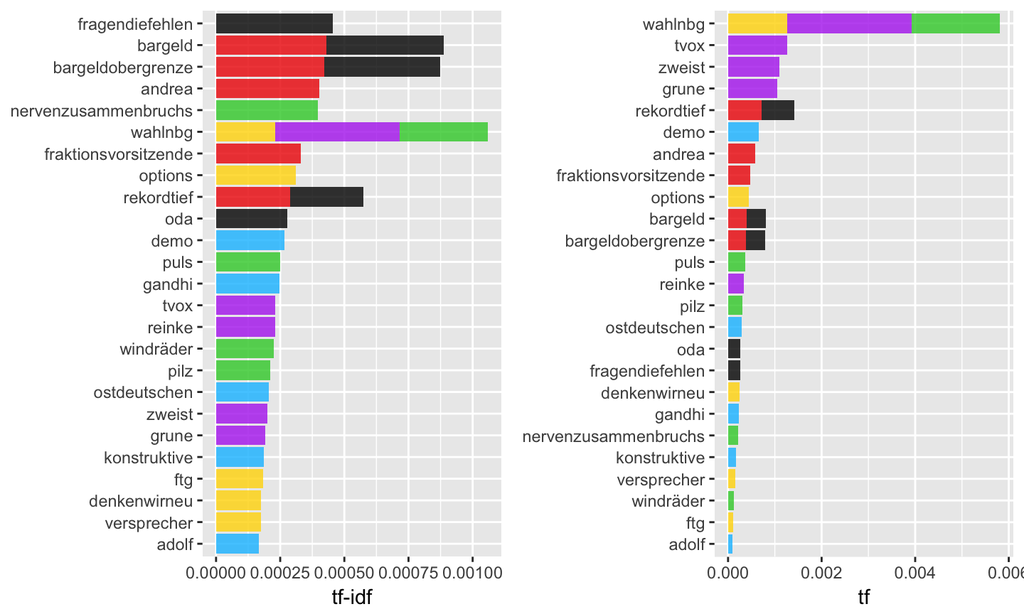

## Statistical Methods

Methods to connect counts \(\boldsymbol{c}_i\) to attributes \(\boldsymbol{v}_i\) can be roughly divided into four categories:

**1. Dictionary-based methods**

**2. Text regression methods**

Directly estimate the conditional outcome distribution \(p(\boldsymbol{v}_i|\boldsymbol{c}_i)\).

**3. Generative model** of \(p(\boldsymbol{c}_i|\boldsymbol{v}_i)\).

**4. Deep learning techniques** neural networks, distributed language models.

## Dictionary-based methods

- In **Tetlock (2007)** \(c_i\) is a bag-of-words representation and the outcome of interest \(v_i\) is the latent “sentiment” of *Wall Street Journal* columns, defined along a number of dimensions such as “positive,” “optimistic,” etc.
- In **Baker et al. (2016)** \(c_i\) is the count of articles in a given newspaper-month containing a set of pre-specified terms such as “policy,” “uncertainty,” and “Federal Reserve,” and the outcome of interest \(v_i\) is the degree of “policy uncertainty” in the economy.

## Text Regression Methods

**Intuition** if we want to predict \(v_i\) from \(c_i\): regress the observed values of the former (\(V^{train}\)) on the corresponding values of the latter (\(C^{train}\))

- Any generic regression technique can be applied, depending upon the nature of \(v_i\)
- high-dimensionality of \(c_i\), (\(p > n^{train}\)), requires use of regression techniques appropriate (e.g. \(L1\) regularized linear or logistic regression)

## Generative Model

**Intuition** In many cases the underlying causal relationship runs from outcomes to language rather than the other way around. (E.g. Google searches about flu do not cause flu cases to occur, rather, people with flu are more likely to produce such searches.)

**1. Observed attributes** (supervised methods):

- Fitting the model based on the observed training data \(\boldsymbol{V}^{train}\), say \(f_{\boldsymbol{\theta}}(\boldsymbol{c}_i;\boldsymbol{v}_i)\) for a vector of parameters \(\boldsymbol{\theta}\), to this training set.
- The fitted model \(f_{\hat{\boldsymbol{\theta}}}\) can be inverted in order to infer \(\boldsymbol{v}_i\) for documents in the test set.

**2. Latent attributes** (unsupervised methods):

- **Starting Point** The true value of \(v_i\) is unobserved -> The function relating \(\boldsymbol{c}_i\) to \(\boldsymbol{v}_i\) is unknown
- **Idea** Uncover hidden patterns that structure the observations in some meaningful way.
- **Use** The outputs of algorithms can be used as inputs into econometric models for predicting some variable of interest.
- **E.g.** Principal Component Analysis, Topic Modeling (latent Dirichlet Allocation)

## Topic Modeling

## Topic Modeling

A method for finding a group of words (i.e topic) from a collection of documents that best represents the information in the collection.

- Discovering **hidden topical patterns** that are present across the collection
- Annotating documents according to these topics
- Using these annotations to organize, search and summarize texts

Very popular topic model is the **Latent Dirichlet allocation**

## Latent Dirichlet Allocation (LDA)

consider the following set of documents as the corpus:

```r
doc1 <- "I had a peanut butter sandwich for breakfast"
doc2 <- "I like to eat almonds, peanut and walnuts."
doc3 <- "My neighbor got a little dog yesterday."
doc4 <- "Cats and dogs are mortal enemies."
doc5 <- "You must not feed peanuts to your dog."
```

This gives the following Document-Term-Matrix

```
## <<DocumentTermMatrix (documents: 5, terms: 20)>>
## Non-/sparse entries: 22/78
## Sparsity           : 78%
## Maximal term length: 9
## Weighting          : term frequency (tf)
## Sample             :
##     Terms
## Docs almonds breakfast butter dog eat got like peanut sandwich walnuts
##    1       0         1      1   0   0   0    0      1        1       0
##    2       1         0      0   0   1   0    1      1        0       1
##    3       0         0      0   1   0   1    0      0        0       0
##    4       0         0      0   0   0   0    0      0        0       0
##    5       0         0      0   1   0   0    0      0        0       0
```